# Impacto del transporte entre la residencia del alumno y la universidad en su tiempo efectivo de trabajo y rendimiento académico

## Título corto: CommUtec

## P3 Tercera Entrega

### **Sección:** 1.01

### **Profesor:** José Miguel Renom

| **Alumno** | **Código** | **Líder** |
| --- | --- | --- |
| Kevin Aubert | 201910019 |  |
| Andrea Chu | 201910124 |  |
| Juan Diego Chu | 201920069 | X |
| Oscar Gómez | 201910179 |  |
| Joaquín Ramírez | 201910277 |  |

### Introducción

El transporte urbano de Lima está en un estado deplorable debido a años de corrupción y manejo indebido de los recursos públicos. Uno de los principales problemas en una sociedad urbanizada es la movilización eficiente de los ciudadanos en el limitado espacio disponible. Según un estudio realizado por la empresa holandesa TomTom (2018), Lima es la tercera ciudad con más tráfico en el mundo. Esto significa que muchos limeños debemos invertir una gran cantidad de horas en transportarnos, debido a que el tráfico nos impide llegar a lugares más rápidamente.

Como estudiantes, consideramos que este tema es importante para nosotros y nuestros compañeros porque todos vivimos en Lima y debemos transportarnos a la universidad frecuentemente. Muchas de estas veces, nos topamos con el tráfico y largas horas de movilidad. Todo esto resulta en una carga físico-emocional que repercute en la vida diaria estudiantil, el cual no nos permite rendir a nuestro máximo potencial.

### Objetivo

El objetivo de esta investigación es analizar e informar acerca del impacto del viaje desde la residencia de un alumno hasta la universidad en su tiempo efectivo de trabajo y rendimiento académico. Con la información recogida, se desea responder a las preguntas planteadas y llegar a conclusiones representativas.

### Factibilidad

El transporte es una actividad en la que participan todos los alumnos con frecuencia diaria (antes de la actual pandemia). La pregunta es: **¿Influye el transporte entre la residencia del alumno a la universidad en su tiempo efectivo de trabajo y rendimiento académico?**

Nuestra actual **hipótesis** es la siguiente: **Sí influye, porque la experiencia de transportarse en Lima causa estrés y cansancio, e implica una cantidad significante de tiempo, lo cual limita nuestra productividad.** De esta manera, es importante entender el comportamiento del alumno analizando el plano mental, pues es el encargado de regir nuestras acciones, lo que tendrá impacto en nuestras notas. Es así que nuestro proyecto buscará comprender el impacto en la salud mental al igual que en el rendimiento académico, valorizando al estudiante en su totalidad.

### Población objetivo

Estudiantes universitarios

### Unidad muestral

Cualquier estudiante de UTEC cursando ciclo II en adelante

### Tipo de muestreo

Muestreo por conveniencia: fácil acceso a nuestra unidad muestral

### Obtención de datos

Al ser parte de la comunidad estudiantil de la misma universidad, tenemos acceso a los medios de comunicación pertinentes para realizar encuestas en línea. Es así que se elaborará una encuesta en SurveyMonkey o GoogleForms, y se distribuirá vía el grupo de Facebook de los alumnos. Si es necesario, solicitaremos ayuda del área de Bienestar Estudiantil, para que nos apoyen con la distribución de la encuesta. Nota: para poder responder las preguntas que toman los factores de opinión y el plano emocional, utilizaremos escalas psicométricas, como la escala de Likert.

### Planificación

Durante las primeras 4 semanas estuvimos planteando el tema y la viabilidad de ellos. Para la siguiente semana desarrollamos las preguntas e identificamos las variables concretas a estudiar. En las siguientes semanas se plantea elaborar la encuesta con la que se recogerán los datos y publicarla por Facebook. En las semanas posteriores se analizarán los datos con R, y se buscará responder las preguntas. Es vital resaltar que conforme recibamos *feedback* del profesor, mejoraremos las entregas del proyecto.

### Preguntas planteadas

| N° | Pregunta | Tipo de pregunta |
| --- | --- | --- |
| 1 | ¿Cuál es la edad de los encuestados? | Descriptiva |
| 2 | ¿Cuánto tiempo les demora a los estudiantes de UTEC llegar a la universidad desde su lugar de residencia? | Descriptiva |
| 3 | ¿Cómo califican los estudiantes la experiencia de transporte? | Descriptiva |
| 4 | ¿Cuál es el medio de transporte más utilizado? | Descriptiva |
| 5 | ¿Qué tan estresados se sentían los alumnos de UTEC el ciclo 2019-2? | Descriptiva |
| 6 | ¿Qué actividades realizarían los alumnos con el tiempo que utilizan para transportarse? | Descriptiva |
| 7 | ¿Que porcentaje de alumnos tienen días con 3 horas o menos de clases?¿Para que porcentaje de alumnos el tiempo de transporte diario es mayor que el número de horas de clase en estos días (3 horas)? | Descriptiva |
| 8 | ¿Existe una relación entre la edad y el tiempo que pasan en el transporte? | Exploratoria |
| 9 | ¿Existe una relación entre el número de horas que duermen los estudiantes y el nivel de estrés que presentan? | Exploratoria |
| 10 | ¿Existe alguna relación entre el tiempo que pasan en el transporte y la cantidad de cursos desaprobados del estudiante? | Exploratoria |
| 11 | ¿Existe alguna relación entre el tiempo que pasan en el transporte y el promedio del estudiante en el ciclo 2019-2? | Exploratoria |
| 12 | ¿Los estudiantes que tienen un mejor percentil son los que se demoran menos horas en transportarse semanalmente? | Inferencial |
| 13 | ¿Los estudiantes que viajan más a la semana dormirán una menor cantidad de horas? | Inferencial |
| 14 | ¿Los estudiantes que viajan menos horas a la semana en el transporte tendrán una mejor calificación de este? | Inferencial |
| 15 | ¿Es posible predecir el nivel de estrés que tendrán los alumnos en base al número de cursos y a la calificación de su experiencia en el transporte? | Predictiva |
| 16 | ¿Es posible predecir la calificación sobre el transporte conociendo únicamente el número de horas que se transportan a la semana? | Predictiva |
| 17 | ¿Qué factores y condiciones en los que se desarrolla el alumno determinan la calificación que tendrás sobre el transporte? | Causal |
| 18 | ¿De qué manera algunos factores afectan la calificación de los alumnos sobre el transporte? | Mecanística |

### Variables identificadas

| Variable | Relación con pregunta | Tipo de variable |
| --- | --- | --- |
| Edad | 1,8 | Numérica discreta |
| Cantidad de cursos que llevó el ciclo 2019-2 | 14 | Numérica discreta |
| Promedio ponderado | 11 | Numérica continua |
| Cantidad de cursos desaprobados | 10 | Numérica discreta |
| Grupo de mérito | 12 | Categórica ordinal |
| Medios de transporte | 4,16,17 | Categórica nominal |
| Experiencia de transporte | 3,14,15,16,17 | Categórica ordinal |
| Tiempo de transporte | 2,7,8,10,11,12,13,16,17 | Numérica continua |
| Actividades que hubieran hecho durante su tiempo de transporte | 6 | Categórica nominal |
| Distrito de Residencia | 16,17 | Categórica nominal |
| Cantidad de días con clases | 8,10,11,12,13 | Numérica discreta |
| Cantidad de horas semanales con clases | 16,17 | Numérica continua |
| Tiempo de sueño | 9,13,16 | Numérica continua |
| Cantidad de días asistidos por clases de duración de tres horas a menos | 7 | Numérica continua |
| Horas invertidas del tiempo libre asignadas para el estudio | 16,17 | Numérica continua |
| Tiempo dedicado a pasatiempos | 11 | Numérica continua |
| Tiempo de transporte semanal | 8,10,11,12 | Numérica continua |
| Nivel de estrés (referencial basado en escala) | 5,9,14 | Numérica discreta |

**Para medir el nivel de estrés utilizaremos el siguiente Cuestionario de Problemas Psicosomáticos(CPP)del Instituto Mexicano del Seguro Social:**

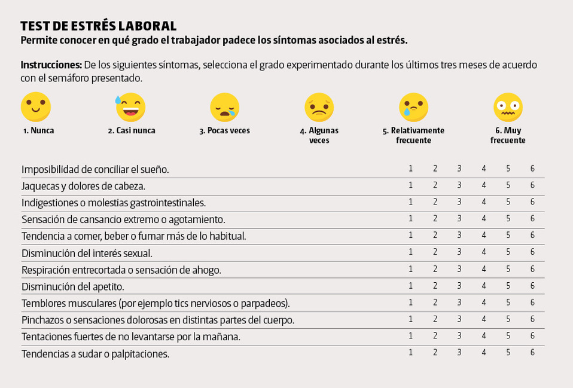

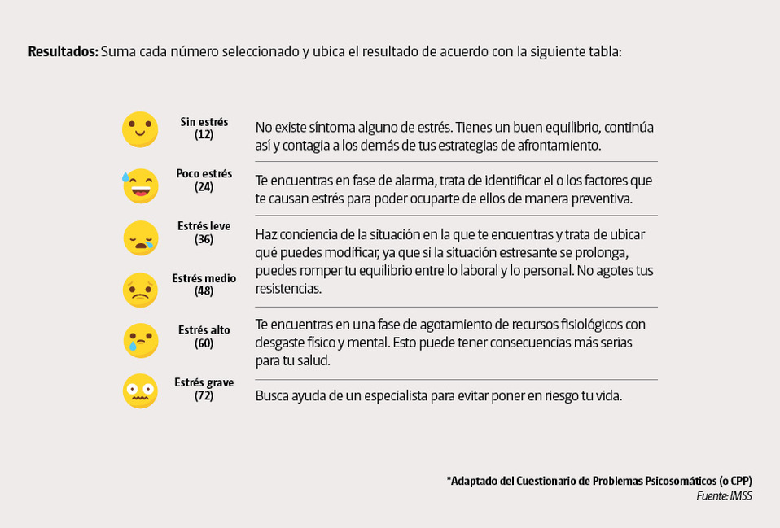

### Base de Datos

```r
library(readr)
library(dplyr)
DF<-read_csv("Base_DatosFINAL.csv")
```

### ¿Cuál es la edad de los encuestados?

**ANÁLISIS:** A partir de las medidas de tendencia central y el diagrama de barras se puede llegar a la conclusión que la moda y la mediana de la variable es 18 y 19, respectivamente; mientras que la media es de 19.18. Esto significa que la variable presenta una distribución sesgada hacia la derecha (media mayor que mediana). Asimismo se obtiene que el rango de edad de los encuestados va desde los 17 años hasta los 24 años y que la mitad de los encuestados tiene 19 años o menos.

```r
summary(DF$Edad)
```

```
##    Min. 1st Qu.  Median    Mean 3rd Qu.    Max.
##   17.00   18.00   19.00   19.18   20.00   24.00
```

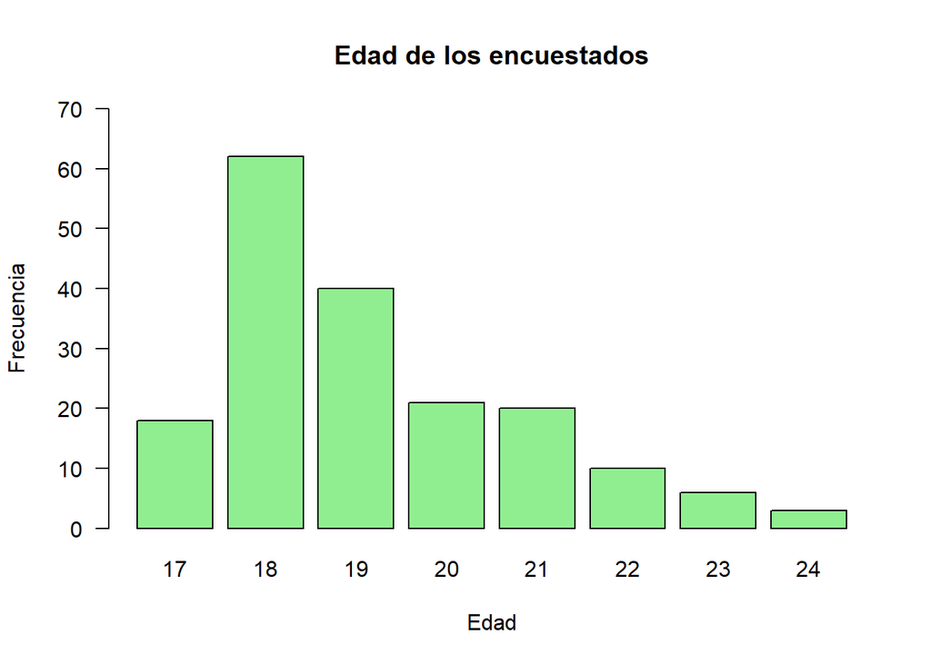

```r
barplot(table(DF$Edad),xlab="Edad", ylab="Frecuencia",main="Edad de los encuestados", col="lightgreen",las=1,cex.names=1,ylim=c(0,70))
```

### ¿Cuánto tiempo les demora a los estudiantes de UTEC llegar a la universidad desde su lugar de residencia?

```r
summary(DF$Tiempo_Transporte/2)
```

```
##    Min. 1st Qu.  Median    Mean 3rd Qu.    Max.
##    2.00   25.00   45.00   51.81   75.00  150.00
```

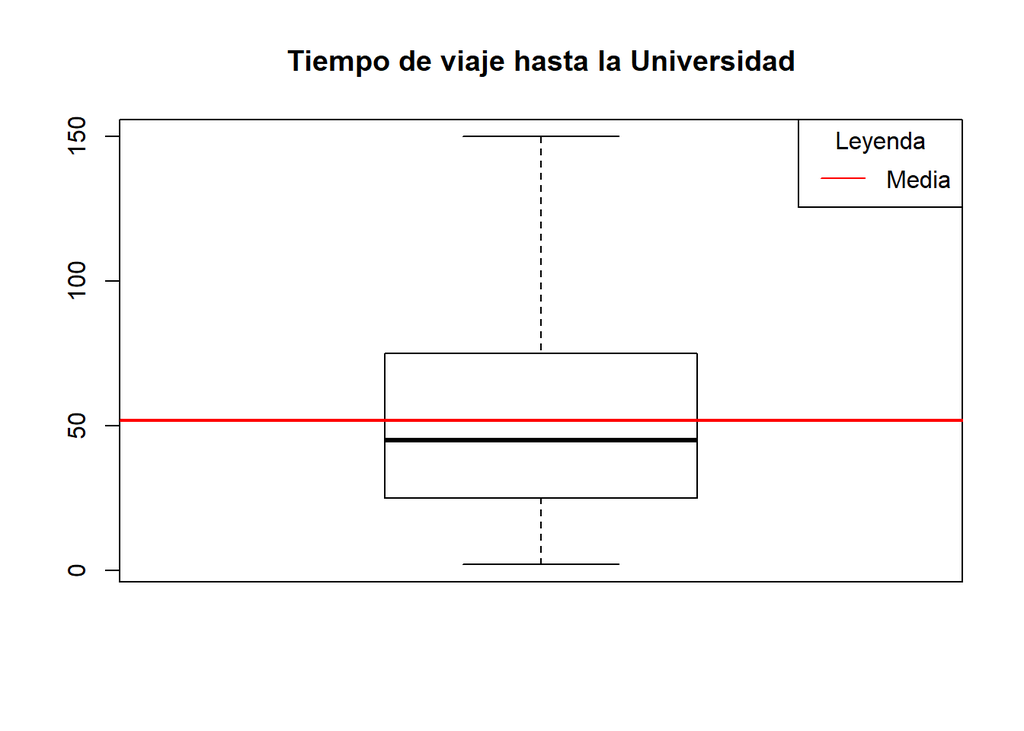

```r
boxplot(DF$Tiempo_Transporte/2)
abline(mean(DF$Tiempo_Transporte/2),0,col="red",title("Tiempo de viaje hasta la Universidad"), lwd=2)
legend("topright",
       c("Media"),
       lty=1,
       col=c("red"),
       bty = "o", title="Leyenda",bg="transparent")
```

### ¿Cómo califican los estudiantes la experiencia de transporte?

**ANÁLISIS:** La gráfica presenta la distribución de la frecuencia referente a la calificación de la experiencia de transporte de los estudiantes de la UTEC. Se puede observar que la mayoría de estudiantes califica el transporte con un valor relativamente alto con una mediana de 7 y una media de 6.572. Basándonos en esto se puede concluir que la mayoría de los estudiantes califica su experiencia de transporte como positiva.

```r
summary(DF$Calificacion)
```

```
##    Min. 1st Qu.  Median    Mean 3rd Qu.    Max.
##   1.000   5.000   7.000   6.572   8.000  10.000
```

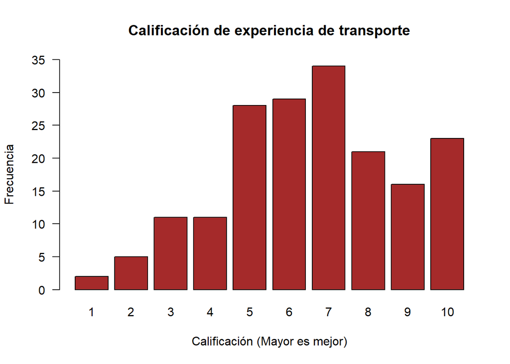

```r
barplot(table(DF$Calificacion), xlab="Calificación (Mayor es mejor)", ylab="Frecuencia", las=1,cex.names=1,ylim=c(0,35), col="brown", main = "Calificación de experiencia de transporte")
```

### ¿Cuál es el medio de transporte más utilizado?

```r
medios <- read_csv("TransporteF.csv") #medios es igual a la suma de M1, M2, M3 Y M4 en DF
```

**Porcentajes de los medios de transporte (%):**

```r
round(table(medios$Actividad)/length(medios$Actividad)*100,2)
```

```
##
##                  A pie              Bicicleta                  Carro
##                    6.0                    9.2                   20.0
## Metropolitano/corredor            Micro/combi        Otro transporte
##                   18.4                   28.0                    3.6
##                   Taxi
##                   14.8
```

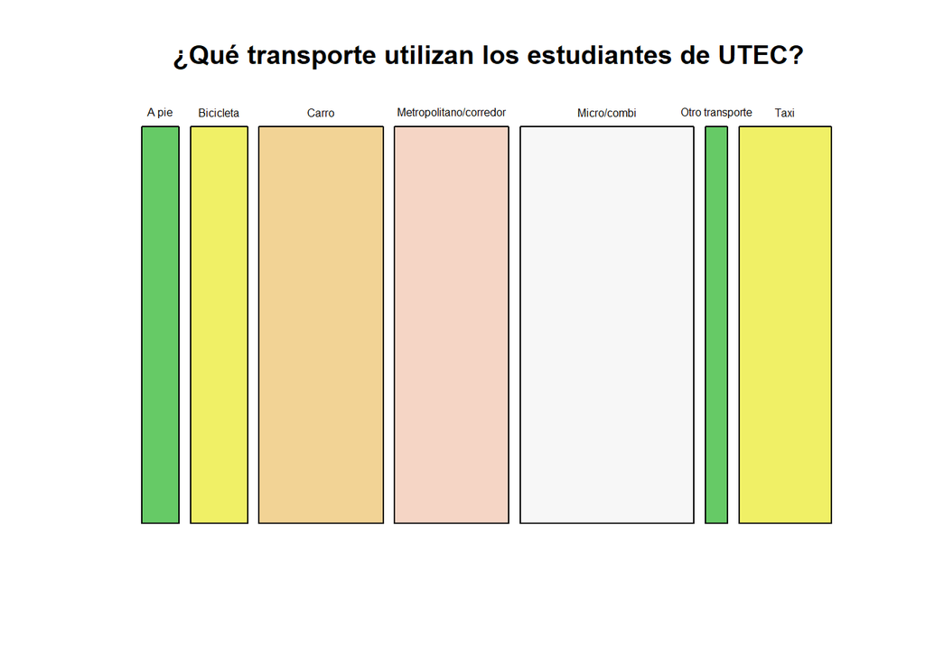

```r
mosaicplot(table(medios$Actividad),
 main="¿Qué transporte utilizan los estudiantes de UTEC?",
 col=terrain.colors(5, alpha = .6), las=1,cex.axis = 0.5)
```

### ¿Qué tan estresados se sentían los alumnos de UTEC el ciclo 2019-2?

**ANÁLISIS:** En el gráfico se puede apreciar que aproximadamente la moda entre los alumnos de UTEC es un nivel de estrés leve, mientras que la mediana es un nivel de estrés medio. Asimismo se sabe que la mayoría de alumnos tienen *Estrés leve (25 a 36) o Estrés medio (37 a 48)* con un porcentaje en los alumnos de 30% y 29.44% respectivamente. Finalmente se observa que la cantidad de alumnos con *Estrés grave* es muy baja, ocurriendo solamente en el 8.33% de los alumnos.

```r
rangos_estres <- round(table((cut(DF$Estres,breaks=seq(12,83,by=12), include.lowest = TRUE)))/nrow(DF),4)*100
```

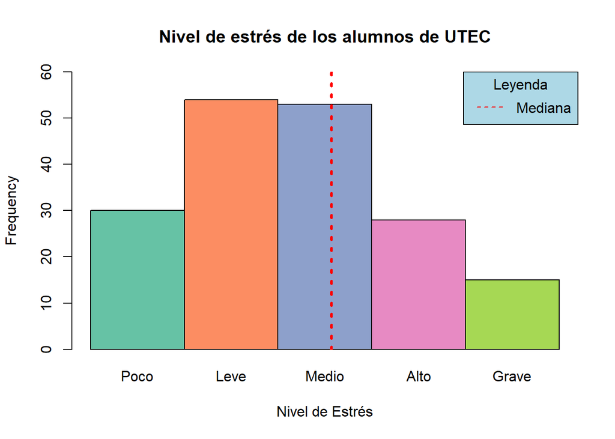

```r
library(RColorBrewer)
coul <- brewer.pal(5, "Set2")
barplot(table((cut(DF$Estres,breaks=seq(12,83,by=12), include.lowest = TRUE))), ylim = c(0,60),col =coul, space = 0,names.arg = c("Poco","Leve","Medio","Alto","Grave"),xlab="Nivel de Estrés", ylab="Frequency",main="Nivel de estrés de los alumnos de UTEC")
legend("topright",
       c("Mediana"),
       lty=c(2, 2),
       col=c("red"),
       bty = "o", title="Leyenda",bg="lightblue")
abline(v=5*median(DF$Estres)/72,col="red", lwd=3,lty=3)
```

**Porcentaje de Niveles de Estrés en Alumnos (%):**

**Poco Estrés:**

```r
rangos_estres[1]
```

```
## [12,24]
##   16.67
```

**Estrés leve:**

```r
rangos_estres[2]
```

```
## (24,36]
##      30
```

**Estrés medio:**

```r
rangos_estres[3]
```

```
## (36,48]
##   29.44
```

**Estrés alto:**

```r
rangos_estres[4]
```

```
## (48,60]
##   15.56
```

**Estrés grave:**

```r
rangos_estres[5]
```

```
## (60,72]
##    8.33
```

### ¿Qué actividades realizarían los alumnos con el tiempo que utilizan para transportarse?

```r
actividades <- read_csv("ActividadF.csv") #medios es igual a la suma de A1, A2, A3, A4 y A5 en DF
```

**Porcentajes de las Actividades que realizarían los estudiantes(%):**

```r
round(table(actividades$Actividad)/length(medios$Actividad)*100,2)
```

```
##
##        Deporte         Dormir       Estudiar Familia/amigos         Idioma
##           31.6           45.6           45.6           20.0            7.6
##           Otra    Videojuegos
##            4.0           20.4
```

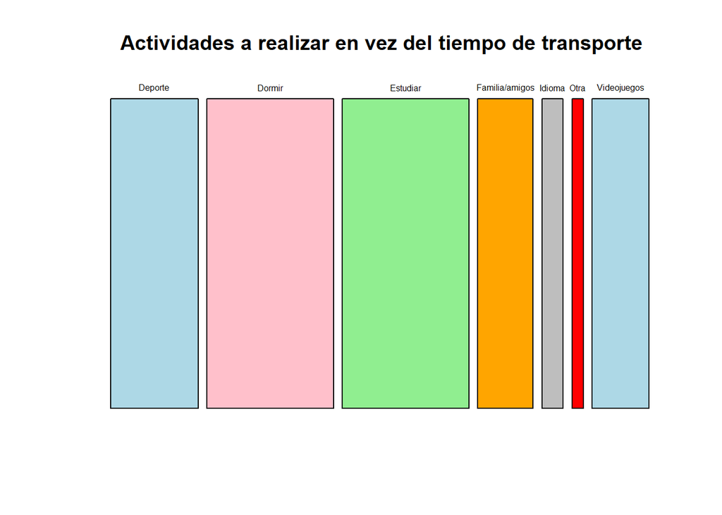

```r
mosaicplot(table(actividades$Actividad),
 main="Actividades a realizar en vez del tiempo de transporte",
  col = c("lightblue","pink","lightgreen", "orange", "gray","red"), las=1,cex.axis = 0.5)
```

### ¿Que porcentaje de alumnos tienen días con 3 horas o menos de clases?¿Para que porcentaje de alumnos el tiempo de transporte diario es mayor que el número de horas de clase en estos días (3 horas)?

**Análisis:** Según la tabla en la que se muestra el número de días que solo tuvieron que asistir a clases por un período de 3 horas a menos, durante el transcurso del ciclo 2019-2, podemos observar que a la mayoría solo le ocurría este suceso una vez a la semana, representando casi en su totalidad el 41.67% de los resultados. Acorde al análisis mostrado obtuvimos que aproximadamente el 11.11% de los entrevistados pasaban más tiempo en el medio de transporte que en sus clases de duración de 3 horas o menos. De este porcentaje se puede resaltar que se divide en cuatro grupos, a los que les sucede 1,2,4 y 5 veces a la semana, siendo el grupo de 1 vez a la semana el mayoritario.

```r
perdida_tiempo<-DF[DF$Dias_Inutiles>0,]
```

**Porcentaje de los días donde los alumnos tiene clases por 3 horas o menos:**

```r
round(100*(table(DF$Dias_Inutiles)/nrow(DF)),2)
```

```
##
##     0     1     2     3     4     5
## 20.56 41.67 24.44  5.00  5.00  3.33
```

**Porcentaje de alumnos que tienen días de clases con 3 horas o menos:**

```r
round(length(perdida_tiempo$Dias_Inutiles)/length(DF$Dias_Inutiles)*100,2)
```

```
## [1] 79.44
```

**Diagrama de barras sobre la cantidad de días a la semana con 3 horas o menos de clase de los alumnos:**

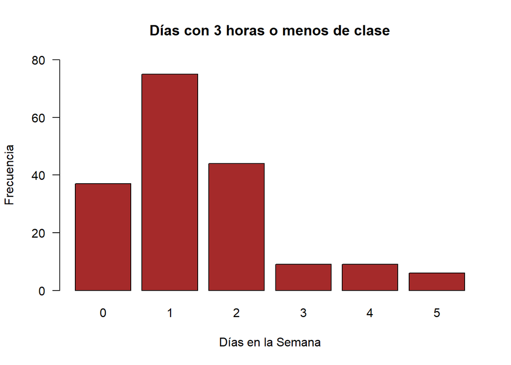

```r
barplot(table(DF$Dias_Inutiles),xlab="Días en la Semana", ylab="Frecuencia",main="Días con 3 horas o menos de clase", col="brown",las=1,cex.names=1,ylim=c(0,80))
```

```r
perdida_total<-perdida_tiempo[perdida_tiempo$Tiempo_Transporte>180,]
```

**Porcentaje de alumnos que tienen días con 3 horas o menos de clases y un tiempo de transporte mayor a 3 horas:**

```r
round(length(perdida_total$Dias_Inutiles)/length(DF$Dias_Inutiles)*100,2)
```

```
## [1] 11.11
```

**Diagrama de barras sobre la cantidad de días con 3 horas o menos de clase semanales de los alumnos cuyo tiempo de transporte es mayor a 3 horas:**

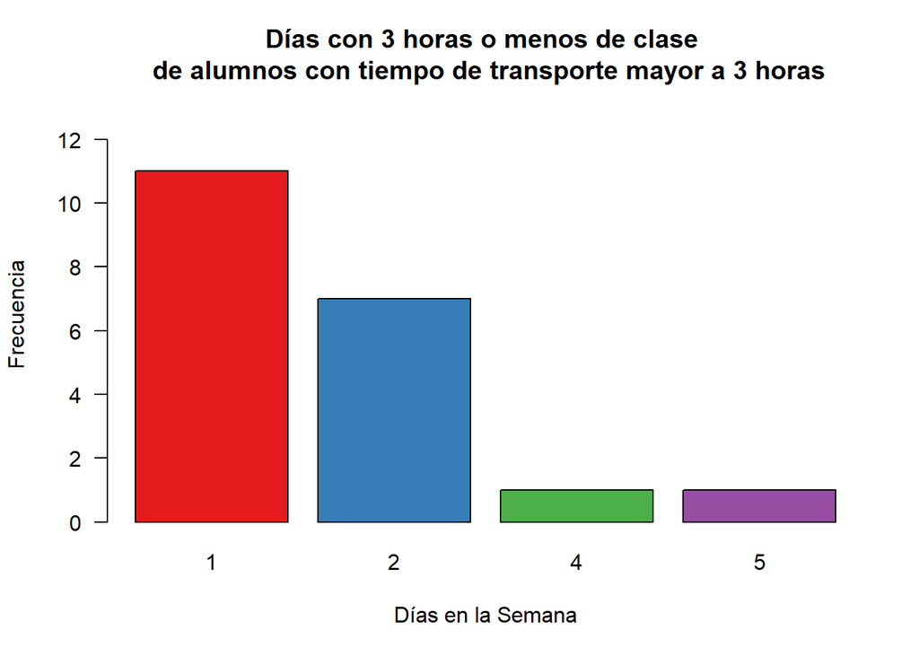

```r
color1 <- brewer.pal(5, "Set1")
barplot(table(perdida_total$Dias_Inutiles),xlab="Días en la Semana", ylab="Frecuencia",main="Días con 3 horas o menos de clase \n de alumnos con tiempo de transporte mayor a 3 horas", col=color1,las=1,cex.names=1,ylim=c(0,13))
```

### Parámetros del estudio

**Tamaño de Muestra:** 180 encuestados

**Nivel de Confianza:** 95% Elegimos un nivel de confianza del 95% puesto que esto significa que si hubiésemos hecho 20 muestreos y creado 20 intervalos de confianza; se esperaría que 19 de ellos contengan la media de la población. Lo cual representa un porcentaje bastante aceptable para una investigación. Además, 95% es el valor que usualmente se utiliza en este tipo de trabajos.

**Nivel de Significancia:** 0.05 El nivel de signifcacia para este caso estará dado por $\alpha=0.05$, el cuál participa en el cálculo del nivel de confianza según la ecuación $1-\alpha= \text{Nivel de confianza}$.

**Tolerancia:** La tolerancia (epsilon) está dada en la fórmula:
$$\mathbb{P}(\left\vert \overline{X}_n - \mu \right\vert \leq \varepsilon)\geq 1-\alpha$$
De la cual se llega a:

$$\varepsilon=\frac{Z_a\sigma}{\sqrt{n}}$$
$$a=\alpha/2$$
Pero como Z es:

```r
alfa<- 0.05
n=180
z<- qnorm(alfa/2, lower.tail = FALSE)
round(z,2)
```

```
## [1] 1.96
```

Finalmente la tolerancia quedaría como:
$$\varepsilon=\frac{1.96 \sigma}{\sqrt{180}}$$
Donde se utiliza el valor de la desviación estándar de cada variable para $sigma$.

### Intervalos de confianza

La fórmula de los intervalos de confianza es la siguiente:
$$[\overline{X}-\varepsilon, \overline{X}+\varepsilon]$$
Usamos la fórmula para hallar los intervalos de confianza de las principaes variables del estudio:

**EDAD:**

```r
E1<-mean(DF$Edad)-1.96*(sd(DF$Edad)/sqrt(180))
E2<-mean(DF$Edad)+1.96*(sd(DF$Edad)/sqrt(180))
E1
```

```
## [1] 18.93599
```

```r
E2
```

```
## [1] 19.41956
```

**Intervalo de Confianza Edad=** [18.93599, 19.41956]

**TIEMPO DE TRANSPORTE**

```r
T1<-mean(DF$Tiempo_Transporte)-1.96*(sd(DF$Tiempo_Transporte)/sqrt(180))
T2<-mean(DF$Tiempo_Transporte)+1.96*(sd(DF$Tiempo_Transporte)/sqrt(180))
T1
```

```
## [1] 93.50854
```

```r
T2
```

```
## [1] 113.7248
```

**Intervalo de Confianza Tiempo de Transporte=** [93.50854, 113.7248]

**TIEMPO DE TRANSPORTE SEMANAL**

```r
TS1<-mean(DF$Transporte_Semanal)-1.96*(sd(DF$Transporte_Semanal)/sqrt(180))
TS2<-mean(DF$Transporte_Semanal)+1.96*(sd(DF$Transporte_Semanal)/sqrt(180))
TS1
```

```
## [1] 470.9605
```

```r
TS2
```

```
## [1] 576.8729
```

**Intervalo de Confianza del Tiempo de Transporte Semanal=** [470.9605, 576.8729]

**PROMEDIO PONDERADO:**

```r
P1<-mean(DF$Promedio)-1.96*(sd(DF$Promedio)/sqrt(180))
P2<-mean(DF$Promedio)+1.96*(sd(DF$Promedio)/sqrt(180))
P1
```

```
## [1] 14.69495
```

```r
P2
```

```
## [1] 15.2175
```

**Intervalo de Confianza del Promedio Ponderado=** [14.69495, 15.2175]

**HORAS DE SUEÑO:**

```r
HS1<-mean(DF$Tiempo_Dormir)-1.96*(sd(DF$Tiempo_Dormir)/sqrt(180))
HS2<-mean(DF$Tiempo_Dormir)+1.96*(sd(DF$Tiempo_Dormir)/sqrt(180))
HS1
```

```
## [1] 6.064808
```

```r
HS2
```

```
## [1] 6.401858
```

**Intervalo de Confianza de Horas de Sueño=** [6.064808, 6.401858]

**NÚMERO DE REPROBADOS**

```r
NR1<-mean(DF$NroReprobados)-1.96*(sd(DF$NroReprobados)/sqrt(180))
NR2<-mean(DF$NroReprobados)+1.96*(sd(DF$NroReprobados)/sqrt(180))
NR1
```

```
## [1] 0.2222577
```

```r
NR2
```

```
## [1] 0.3888535
```

**Intervalo de Confianza de Número de Reprobados=** [0.2222577, 0.3888535]

### ¿Existe una relación entre la edad y el tiempo de transporte diario?

**Relevancia en el estudio:** Esta pregunta es relevante al estudio ya que nos permite hallar si es que hay una relación entre la edad de los estudiantes y el tiempo que les toma transportarse hacia la universidad. Esto nos puede ayudar a verificar si nuestra hipótesis nula se cumple y si hay otros factores aparte de la edad que alteren la relación de estas variables.

```r
summary(DF$Edad)
```

```
##    Min. 1st Qu.  Median    Mean 3rd Qu.    Max.
##   17.00   18.00   19.00   19.18   20.00   24.00
```

Tomaremos como referencia el valor de la media de la edad **(19.18 años)**, los valores por encima de esta serán calificados como alumnos mayores y los valores por debajo de esta como alumnos menores. Esta pregunta es relevante porque nos permite hallar una relación o vinculo con los alumnos de últimos ciclos y su tiempo de transporte diario.

```r
mayores<-(DF[which(DF$Edad>19.18),])
menores<-(DF[which(DF$Edad<=19.18),])
summary(mayores$Tiempo_Transporte)
```

```
##    Min. 1st Qu.  Median    Mean 3rd Qu.    Max.
##    4.00   43.75  100.00  106.20  152.50  300.00
```

Asimismo, consideraremos un alto tiempo de transporte cuando este se ubique por encima de la media de **106.20 minutos**.

**H0:** A mayor la edad de los estudiantes, el tiempo de transporte diario es mayor.

**H1:** A mayor la edad de los estudiantes, el tiempo de transporte diario es menor.

**Nivel de confianza:** 95%

**alpha**=0.05

```r
t.test(mayores$Tiempo_Transporte,mu=106.2, alternative="greater", conf.level = 0.95)
```

```
##
##  One Sample t-test
##
## data:  mayores$Tiempo_Transporte
## t = 0, df = 59, p-value = 0.5
## alternative hypothesis: true mean is greater than 106.2
## 95 percent confidence interval:
##  91.15194      Inf
## sample estimates:
## mean of x
##     106.2
```

**ANÁLISIS:** Como p-value es mayor que nuestro alpha **(0.5>0.05)** no se puede descartar satisfactoriamente la hipótesis nula declarándola estadisticamente insignificante. Utilizando el boxplot a continuación se traza su mediana y se puede apoyar al descarte de ambas hipótesis ya que el tiempo y la edad del estudiante no tienen una relación observable en este gráfico.

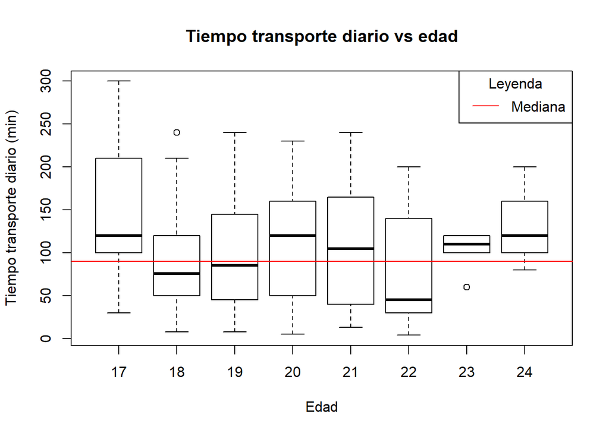

```r
  boxplot(DF$Tiempo_Transporte~DF$Edad,main="Tiempo transporte diario vs edad", xlab= "Edad",ylab="Tiempo transporte diario (min)")
abline(h=median(DF$Tiempo_Transporte),col="red")
legend("topright", c("Mediana"),lty=c(1), col=c("red"),title="Leyenda",bg="white")
```

### ¿Existe alguna relación entre el tiempo que pasan en el transporte y la cantidad de cursos desaprobados del estudiante?

**Relevancia para el estudio:**Esta Pregunta es relevante al estudio ya que nos permite averiguar la relación que tienen los estudiantes que se toman más tiempo en transportarse hacia la universidad y cuantos cursos desaprobados tuvieron. Además de estas dos variables, también nos permitirá relacionar el tiempo de transporte con promedio ponderado ya que un curso reprobado reducirá este.

Filtraremos los resultados para obtener a los estudiantes que reprobaron uno o más cursos, luego analizaremos si hay una relación entre el numero de reprobados y el tiempo de transporte hacia la universidad.

```r
jalados<-(DF[which(DF$NroReprobados>=1),])
summary(jalados$Tiempo_Transporte)
```

```
##    Min. 1st Qu.  Median    Mean 3rd Qu.    Max.
##     8.0    50.0   120.0   118.2   180.0   300.0
```

Utilizaremos el valor de la media del tiempo **(118.2)** para diferenciar a la mitad superior e inferior, en tiempo de transporte, de las personas que reprobaron uno o más cursos.

**H0:** Los alumnos que pasan un mayor tiempo al transportarse hacia la universidad tendrán un mayor número de cursos desaprobados.

**H1:** Los alumnos que pasan un mayor tiempo al transportarse hacia la universidad tendrán un menor número de cursos desaprobados.

**Nivel de confianza:** 95%

**alpha**=0.05

```r
t.test(jalados$Tiempo_Transporte,mu=118.2,alternative = "greater",conf.level = 0.95)
```

```
##
##  One Sample t-test
##
## data:  jalados$Tiempo_Transporte
## t = -0.0020999, df = 44, p-value = 0.5008
## alternative hypothesis: true mean is greater than 118.2
## 95 percent confidence interval:
##  100.3965      Inf
## sample estimates:
## mean of x
##  118.1778
```

**ANÁLISIS:** Como el p-value es mayor a nuestro alpha, **(0.5008>0.05)**, no es posible descartar satisfactoriamente la hipótesis nula declarándola estadísticamente insignificante. Sin embargo, al graficar un boxplot se puede observar una ligera tendencia relacionando un mayor tiempo de transporte con un incremento de cursos desaprobados. Utilizando esta información se podría apoyar nuestra hipótesis nula pero es necesario realizar pruebas adicionales.

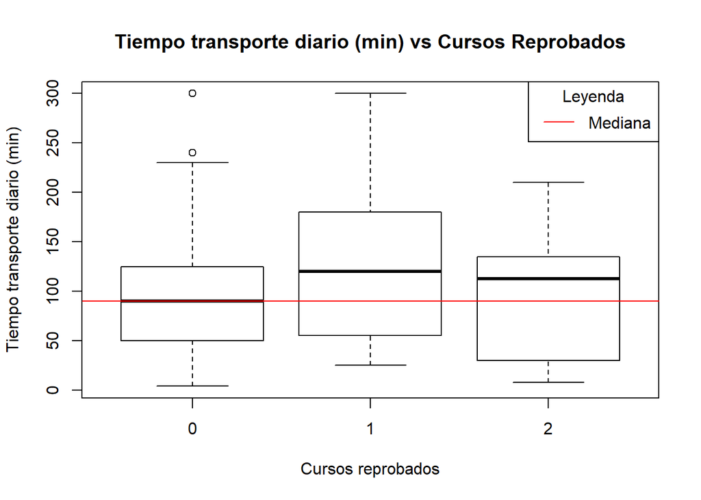

```r
boxplot(DF$Tiempo_Transporte~DF$NroReprobados,main="Tiempo transporte diario (min) vs Cursos Reprobados", xlab= "Cursos reprobados",ylab="Tiempo transporte diario (min)")
abline(h=median(DF$Tiempo_Transporte),col="red")
legend("topright", c("Mediana"),lty=c(1), col=c("red"),title="Leyenda",bg="white")
```

### ¿Existe alguna relación entre el tiempo que pasan en el transporte y el promedio del estudiante en el ciclo 2019-2?

**Relevancia:**Esta pregunta es relevante hacia la investigación ya que nos permite relacionar el tiempo de transporte con el promedio ponderado del alumno. Además, esta pregunta ayuda a complementar la pregunta anterior ya que brinda mayor detalle sobre el encuestado.

```r
summary(DF$Tiempo_Transporte)
```

```
##    Min. 1st Qu.  Median    Mean 3rd Qu.    Max.
##     4.0    50.0    90.0   103.6   150.0   300.0
```

Utilizaremos la media de tiempo de transporte **(103.6 minutos)** para separar a los alumnos con mayor tiempo de transporte hacia la universidad.

```r
promdemora<-(DF[which(DF$Tiempo_Transporte>103.6),])
summary(promdemora$Promedio)
```

```
##    Min. 1st Qu.  Median    Mean 3rd Qu.    Max.
##   10.65   13.00   14.50   14.44   15.80   19.00
```

Utilizaremos la mediana del promedio ponderado para hallar a los alumnos con promedio ponderado menor a esta.

**H0:** Los alumnos que pasan más tiempo transportándose tendrán un menor promedio ponderado.

**H1:** El tiempo ponderado sí influye en el promedio ponderado del alumno

**Nivel de confianza:** 95%

**alpha**=0.05

```r
t.test(promdemora$Promedio, mu=14.44, alternative = "greater",conf.level = 0.95)
```

```
##
##  One Sample t-test
##
## data:  promdemora$Promedio
## t = 0.020797, df = 77, p-value = 0.4917
## alternative hypothesis: true mean is greater than 14.44
## 95 percent confidence interval:
##  14.10553      Inf
## sample estimates:
## mean of x
##  14.44423
```

**ANÁLISIS:** Como el p-value es mayor a nuestro alpha, **(0.4917>0.05)**, no es posible descartar satisfactoriamente la hipótesis nula declarándola estadisticamente insignificante. Al filtrar a los estudiantes por tiempos de **0-100 Minutos**, **100-200 Minutos** y **200-300 Minutos** observamos que la media y la mediana no varían de una manera que apoye nuestra hipótesis nula.

```r
t_0_100<-(DF[which(DF$Tiempo_Transporte<=100),])
t_100_200<-(DF[which(DF$Tiempo_Transporte>100 & DF$Tiempo_Transporte<=200),])
t_200_300<-(DF[which(DF$Tiempo_Transporte>200),])
"Mediana y media del promedio para un tiempo de transporte entre 0 y 100 minutos"
```

```
## [1] "Mediana y media del promedio para un tiempo de transporte entre 0 y 100 minutos"
```

```r
summary(t_0_100$Promedio)
```

```
##    Min. 1st Qu.  Median    Mean 3rd Qu.    Max.
##   11.25   14.00   15.38   15.35   16.51   19.38
```

```r
"Mediana y media del promedio para un tiempo de transporte entre 100 y 200 minutos"
```

```
## [1] "Mediana y media del promedio para un tiempo de transporte entre 100 y 200 minutos"
```

```r
summary(t_100_200$Promedio)
```

```
##    Min. 1st Qu.  Median    Mean 3rd Qu.    Max.
##   10.65   13.04   14.15   14.24   15.60   17.25
```

```r
"Mediana y media del promedio para un tiempo de transporte entre 200 y 300 minutos"
```

```
## [1] "Mediana y media del promedio para un tiempo de transporte entre 200 y 300 minutos"
```

```r
summary(t_200_300$Promedio)
```

```
##    Min. 1st Qu.  Median    Mean 3rd Qu.    Max.
##   12.00   13.00   15.90   15.11   16.55   19.00
```

**Relevancia para el estudio:** Esta pregunta es relevante al estudio ya que nos permite hallar la relación entre el grado de mérito del estudiante y las horas que se transporta al día. Esto es importante al estudio ya que permite diferenciar mas allá del promedio ponderado ya que cada carrera tiene diferentes promedios.

```r
summary(DF$Tiempo_Transporte)
```

```
##    Min. 1st Qu.  Median    Mean 3rd Qu.    Max.
##     4.0    50.0    90.0   103.6   150.0   300.0
```

Para responder esta pregunta se tomará de referencia la media del tiempo de transporte diario: **103.6** minutos, y nos referiremos a ‘transportarse por poco tiempo’ a tener un tiempo de transporte menor a este valor. Además, consideraremos ‘grado de mérito alto’ a los percentiles de décimo, quinto y tercio superior.

**H0:** Los alumnos que se transportan por poco tiempo tendrán un grado de mérito alto. **H1:** Los alumnos que se transportan por poco tiempo no tendrán un grado de mérito más bajo

**Nivel de confianza:** 95%

**alpha**=0.05

```r
DF%>%filter(Percentil!="Menos de tercio superior")->percentil
```

```r
t.test(percentil$Tiempo_Transporte, mu=103.6, alternative="less", conf.level = 0.95)
```

```
##
##  One Sample t-test
##
## data:  percentil$Tiempo_Transporte
## t = 0.0032317, df = 179, p-value = 0.5013
## alternative hypothesis: true mean is less than 103.6
## 95 percent confidence interval:
##      -Inf 112.1436
## sample estimates:
## mean of x
##  103.6167
```

Como el p-value es mayor a alpha **0.5013>0.05**, no se puede rechazar la hipótesis H0. Esta hipótesis se puede apoyar en el siguiente gráfico. La media de transporte está representada por la línea roja. Se puede observar que la media de tiempo de transporte diario de los percentiles mayores (décimo, quinto y tercio superior) se encuentran debajo de la media, mientras que la media de los percentiles bajos se encuentra encima de la media.

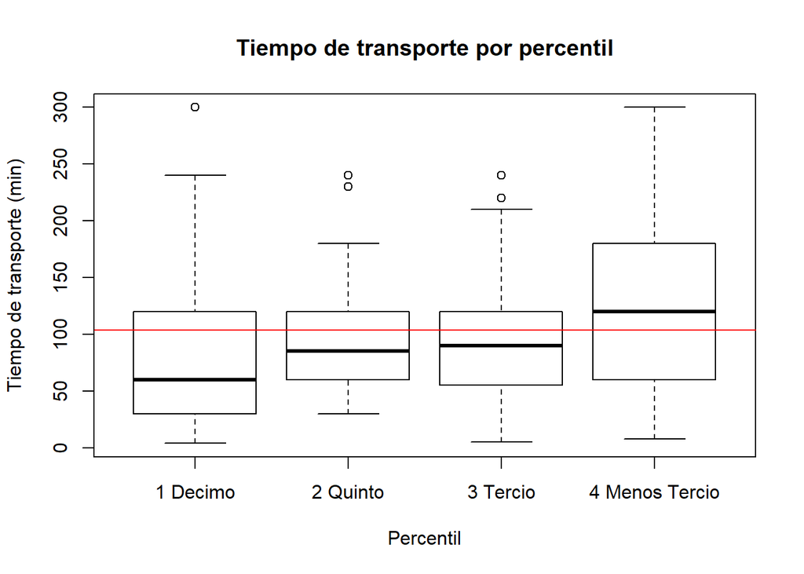

```r
boxplot(DF$Tiempo_Transporte~DF$Percentil, main="Tiempo de transporte por percentil", ylab="Tiempo de transporte (min)", xlab="Percentil")
abline(h=mean(DF$Tiempo_Transporte), col="red")
```

**Relevancia para el estudio:** Esta pregunta es relevante al estudio ya que nos permite relacionar el tiempo de sueño de un estudiante con las horas que este duerme a la semana. Estudios demuestran que la falta de sueño afecta la salud, el rendimiento académico y el nivel de estrés y queríamos ver si había una relación directa entre tiempo de sueño y tiempo de transporte semanal.

```r
summary(DF$Tiempo_Dormir)
```

```
##    Min. 1st Qu.  Median    Mean 3rd Qu.    Max.
##   3.000   6.000   6.000   6.233   7.000   8.000
```

Utilizaremos la media de **6.233h** como punto medio para separar a los estudiantes que duermen más o menos que el promedio.

```r
duermemenos<-(DF[which(DF$Tiempo_Dormir<6.233),])
summary(duermemenos$Tiempo_Transporte)
```

```
##    Min. 1st Qu.  Median    Mean 3rd Qu.    Max.
##     5.0    60.0   120.0   116.9   180.0   300.0
```

Utilizaremos la media del tiempo de transporte de los estudiantes que duermen menos de 6.233h para verificar nuestra hipótesis **(116.9 min)**.

**H0:** A menor tiempo de sueño del estudiante, mayor será el tiempo de transporte hacia la universidad.

**H1:** A menor tiempo de sueño del estudiante, menor será el tiempo de transporte hacia la universidad.

**Nivel de confianza:** 95%

**alpha**=0.05

```r
t.test(duermemenos$Tiempo_Transporte,mu=116.9,alternative = "greater", conf.level = 0.95)
```

```
##
##  One Sample t-test
##
## data:  duermemenos$Tiempo_Transporte
## t = 0.00081813, df = 105, p-value = 0.4997
## alternative hypothesis: true mean is greater than 116.9
## 95 percent confidence interval:
##  105.4242      Inf
## sample estimates:
## mean of x
##  116.9057
```

**ANÁLISIS:** Como el p-value es mayor a nuestro alpha, **(0.4997>0.05)**, no es posible descartar satisfactoriamente la hipótesis nula declarándola estadísticamente insignificante. Se filtraron los resultados en dos rangos de tiempo de sueño **5h o menos** y **6h o más** y los resultados de la media y la mediana apoyaban nuestra hipótesis nula demostrando que los alumnos que dormían 6h o más tenían un menor tiempo de transporte que los estudiantes que dormían 5h o menos.

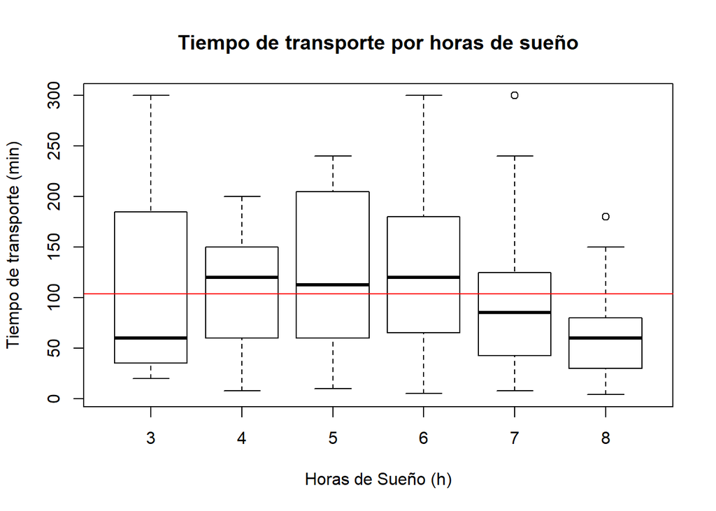

```r
boxplot(DF$Tiempo_Transporte~DF$Tiempo_Dormir, main="Tiempo de transporte por horas de sueño", ylab="Tiempo de transporte (min)", xlab="Horas de Sueño (h)")
abline(h=mean(DF$Tiempo_Transporte), col="red")
```

```r
s_3_5<-(DF[which(DF$Tiempo_Dormir<=5.5),])
s_6_8<-(DF[which(DF$Tiempo_Dormir>5.5),])
"Mediana y media del tiempo de transporte para 5 horas o menos de sueño"
```

```
## [1] "Mediana y media del tiempo de transporte para 5 horas o menos de sueño"
```

```r
summary(s_3_5$Tiempo_Transporte)
```

```
##    Min. 1st Qu.  Median    Mean 3rd Qu.    Max.
##     8.0    60.0   105.0   115.8   190.0   300.0
```

```r
"Mediana y media del tiempo de transporte para 6 horas o más de sueño"
```

```
## [1] "Mediana y media del tiempo de transporte para 6 horas o más de sueño"
```

```r
summary(s_6_8$Tiempo_Transporte)
```

```
##    Min. 1st Qu.  Median    Mean 3rd Qu.    Max.
##     4.0    50.0    90.0    99.8   135.0   300.0
```

### Conclusiones parte inferencial

**1.** No se halló una relación clara entre las variables de edad de los encuestados y tiempo de viaje, debido a que no se puede descartar satisfactoriamente la hipótesis 0 y no hay suficiente información que demuestre que la hipótesis 1 no se deba rechazar.

**2.**Al analizar el efecto del tiempo de transporte en la cantidad de cursos desaprobados y en el promedio ponderado, no se puede descartar satisfactoriamente la hipótesis nula, y al graficar los datos se hallaron ligeras tendencias. Sin embargo, aún es necesario analizar a más profundidad las relaciones entre estas variables, lo cual se podría lograr usando otros métodos, como la regresión.

### Bibliografía:

- https://gestion.pe/tendencias/lima-ciudades-peor-trafico-269483-noticia/
- https://amp.milenio.com/especiales/estres-cronico-como-identificarlo